# Lecture Script - Survival Analysis

Bioengineering Statistics (MA482/BE482)

```r
# This line should be the first line of code executed in your document. It
# ensures that additional functionality is available to you.
source("https://reyesem.github.io/files/MA482/MA482Setup.R")
```

This module contains code for modeling a time-to-event variable when the response is subject to censoring.

Keep in mind that while we are studying a different modeling technique, many of the modeling strategies introduced earlier in the course are still available to us.

# Censoring and Estimation

This section examines some of the non-parametric approaches to the estimation of survival.

## Life Table Methods

For the hypertension example, we can use the `LifeTable()` function to compute the components of a lifetable. What is returned is a dataset. Note that this is a function custom written for this class.

```r
hyper <- read_csv("Hypertension.csv")
```

The `LifeTable()` function takes the number at risk, the number of events and the number of censored observations in each interval. By default, a 95% confidence interval is computed.

```r
LifeTable(Nrisk, Ndied, Ncensored, data = hyper)
```

```
 Number at Risk Number of Events Number Censored Mortality Survival
            146               27               3     0.187    0.813
            116               18              10     0.162    0.681
             88               21              10     0.253    0.509
             57                9               3     0.162    0.426
             45                1               3     0.023    0.417
             41                2              11     0.056    0.393
             28                3               5     0.118    0.347
             20                1               8     0.062    0.325
             11                2               1     0.190    0.263
              8                2               6     0.400    0.158
 Std. Error Lower CL Upper CL
      0.075    0.666    0.960
      0.095    0.496    0.867
      0.096    0.321    0.697
      0.102    0.227    0.626
      0.118    0.185    0.648
      0.131    0.137    0.649
      0.136    0.079    0.614
      0.153    0.025    0.625
      0.153    0.000    0.564
      0.130    0.000    0.412
```

## Kaplan-Meier Estimation

For the bone marrow example, we can compute the Kaplan-Meier estimates of survival, which generalizes the life-table methods. While the procedure produces the survival at any point in the study time frame, most people associate “Kaplan-Meier” with the graphical representation of the estimate — survival curves.

In order to get the survival estimates for each of the two types separately, we give `type` as the only categorical predictor in the formula.

```r
bone <- read_csv("Alloauto.csv")
```

```r
bone.km <- survfit(Surv(time, delta) ~ type, data = bone)

bone.km <- tidy(bone.km)
```

The first few records of the resulting dataset are shown below:

| time | n.risk | n.event | n.censor | estimate | std.error | conf.high | conf.low | strata |
| --- | --- | --- | --- | --- | --- | --- | --- | --- |
| 0.030 | 50 | 1 | 0 | 0.98 | 0.0202 | 1.0000 | 0.9420 | type=allogeneic |
| 0.493 | 49 | 1 | 0 | 0.96 | 0.0289 | 1.0000 | 0.9072 | type=allogeneic |
| 0.855 | 48 | 1 | 0 | 0.94 | 0.0357 | 1.0000 | 0.8764 | type=allogeneic |
| 1.184 | 47 | 1 | 0 | 0.92 | 0.0417 | 0.9984 | 0.8478 | type=allogeneic |
| 1.283 | 46 | 1 | 0 | 0.90 | 0.0471 | 0.9871 | 0.8206 | type=allogeneic |
| 1.480 | 45 | 1 | 0 | 0.88 | 0.0522 | 0.9748 | 0.7944 | type=allogeneic |

We can graphically summarize the data using `ggplot()` combined with `geom_step()`. This is important because survival curves are by nature step functions. In order to make the graphic production quality, we must also clean up the `strata` variable.

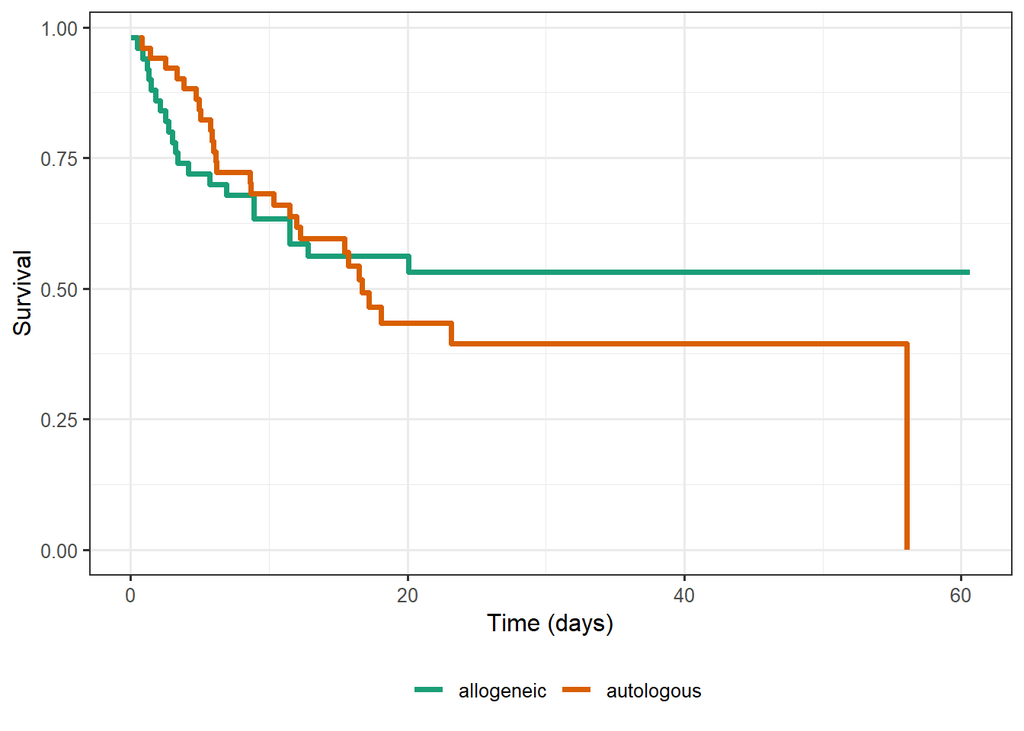

```r
bone.km <- bone.km %>%
  mutate(strata = recode(strata,
                         "type=allogeneic" = "allogeneic",
                         "type=autologous" = "autologous"))

ggplot(data = bone.km,
       mapping = aes(y = estimate, x = time, color = strata)) +
  geom_step(size = 1.25) +
  labs(y = "Survival",
       x = "Time (days)",
       color = "") +
  scale_color_brewer(type = "qual", palette = "Dark2")
```

## Log-Rank Tests

To formally compare the survival between the two types of treatment in the bone marrow example, we can use the log-rank test. As this test is nonparametric, it only requires a large enough sample size.

The formula is similar to creating Kaplan-Meier curves.

```r
bone.logrank <- survdiff(Surv(time, delta) ~ type, data=bone)

tidy(bone.logrank)
```

```
# A tibble: 2 x 4
  type           N   obs   exp
  <chr>      <dbl> <dbl> <dbl>
1 allogeneic    50    22  24.2
2 autologous    51    28  25.8
```

```r
glance(bone.logrank)
```

```
# A tibble: 1 x 3
  statistic    df p.value
      <dbl> <dbl>   <dbl>
1     0.382     1   0.537
```

## Cox PH Models

The most common type of regression model in survival analysis is the Cox PH model. As in this example, the regression model will allow us to examine the survival as a function of several predictors. We consider a study comparing two types of transplants after accounting for various confounders.

First, we use KM Curves to compare the (unadjusted) survival of the two types of transplants.

```r
hodgkins <- read_csv("Hodgkins.csv")
```

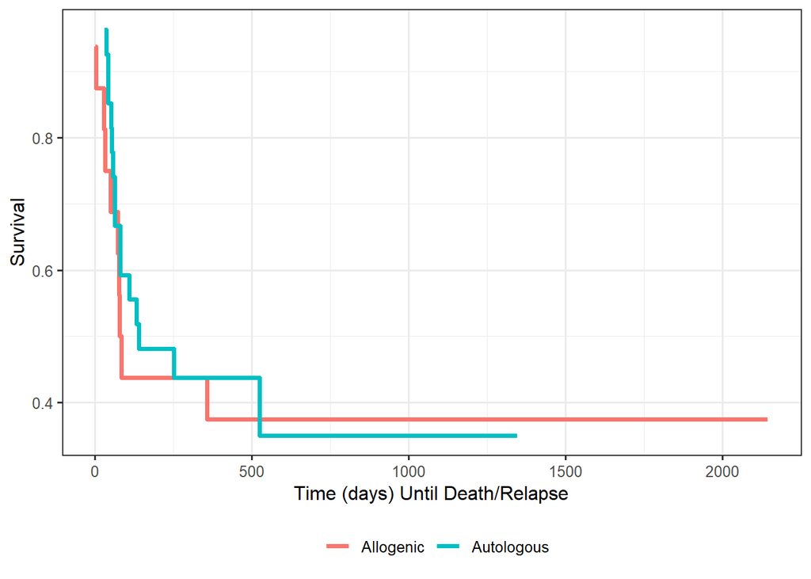

```r
hodgkins.km <- survfit(Surv(time, delta) ~ gtype, data = hodgkins)
hodgkins.km <- tidy(hodgkins.km) %>%
  mutate(strata = recode(strata,
                         "gtype=allogenic" = "Allogenic",
                         "gtype=autologous" = "Autologous"))

ggplot(data = hodgkins.km,
       mapping = aes(y = estimate, x = time, color = strata)) +
  geom_step(size = 1.25) +
  labs(y = "Survival",
       x = "Time (days) Until Death/Relapse",
       color = "")
```

We should keep in mind that the above plot is *unadjusted*; that is, confounders could be driving the relationship (or lack thereof) that we observe. To adjust for the potential confounding, we fit a Cox PH model.

```r
fit.hodgkins <- coxph(Surv(time, delta) ~ gtype + dtype + wtime + score,
                      data = hodgkins)

tidy(fit.hodgkins, conf.int = TRUE, conf.level = 0.95)
```

```
# A tibble: 4 x 7
  term            estimate std.error statistic   p.value conf.low conf.high
  <chr>              <dbl>     <dbl>     <dbl>     <dbl>    <dbl>     <dbl>
1 gtypeautologous -0.233     0.443      -0.527   5.98e-1  -1.10     0.635
2 dtypeNon-Hodgk~ -0.981     0.523      -1.88    6.06e-2  -2.01     0.0437
3 wtime           -0.00786   0.00789    -0.997   3.19e-1  -0.0233   0.00759
4 score           -0.0558    0.0122     -4.59    4.36e-6  -0.0797  -0.0320
```

Similar to `survfit()`, the response is a `Surv()` object which specifies the event time and the censoring indicator. The predictors are included as you would in `lm()`. Of course, the estimates are log-hazard ratios. To get hazard ratios, we need to exponentiate:

```r
tidy(fit.hodgkins, conf.int = TRUE, conf.level = 0.95) %>%
  mutate(estimate = exp(estimate),
         conf.low = exp(conf.low),
         conf.high = exp(conf.high))
```

```
# A tibble: 4 x 7
  term            estimate std.error statistic   p.value conf.low conf.high
  <chr>              <dbl>     <dbl>     <dbl>     <dbl>    <dbl>     <dbl>
1 gtypeautologous    0.792   0.443      -0.527   5.98e-1    0.332     1.89
2 dtypeNon-Hodgk~    0.375   0.523      -1.88    6.06e-2    0.135     1.04
3 wtime              0.992   0.00789    -0.997   3.19e-1    0.977     1.01
4 score              0.946   0.0122     -4.59    4.36e-6    0.923     0.968
```

We see that there is no evidence that the type of transplant makes a difference after accounting for the disease status or other confounders.